# Spatio-molecular gene expression reflects dorsal anterior cingulate cortex structure and function in the human brain

## Overview

Welcome to the `spatial_dACC` project! In this study, we generated spatially-resolved transcriptomics (SRT) and single-nucleus RNA-sequencing (snRNA-seq) data from adjacent tissue sections of the dorsal anterior cingulate cortex across ten adult neurotypical donors. SRT data was generated using [10x Genomics **Visium**](https://www.10xgenomics.com/products/spatial-gene-expression) (n=17 capture areas). snRNA-seq data was generated using [10x Genomics **Chromium**](https://www.10xgenomics.com/products/single-cell-gene-expression) (n=10 total snRNA-seq libraries).

Thank you for your interest in our work!

## Study design

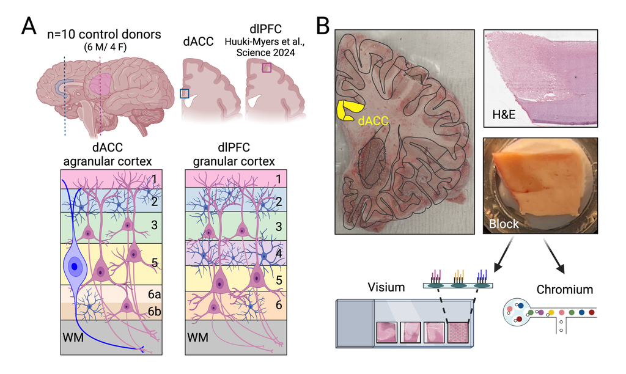

Experimental design to generate paired single-nucleus RNA-sequencing (snRNA-seq) and spatially-resolved transcriptomics (SRT) data in the human dorsal anterior cingulate cortex. (A) dACC (blue) and dlPFC (pink) outlined at midsagittal (dACC) and lateral (dlPFC) levels as well as in a coronal hemislabs (top). dACC tissue (blue) used here was sourced from the same n=10 neurotypical control donors previously similarly profiled for dlPFC (pink) to facilitate within-donor comparisons of dACC agranular cortex vs. dlPFC granular cortex (bottom).

## How to Cite

Shah, K. et al. Spatio-molecular gene expression reflects dorsal anterior cingulate cortex structure and function in the human brain. BioRxiv (2025) doi:10.1101/2025.07.14.664821.